# Лабораторная 5. Анализ остатков

Natalia Korskova

### Вариант 4. Monthly milk production per cow over 14 years

Построить прогноз на 8 месяцев.

Считываем данные и смотрим на структуру:

```r
milk <- read.table("milk.csv", header = TRUE)
str(milk)
```

```
## 'data.frame':    168 obs. of  1 variable:
##  $ milk: int  589 561 640 656 727 697 640 599 568 577 ...
```

В данных только показания производства молока за 14 лет, самих дат нет. Построим график ряда:

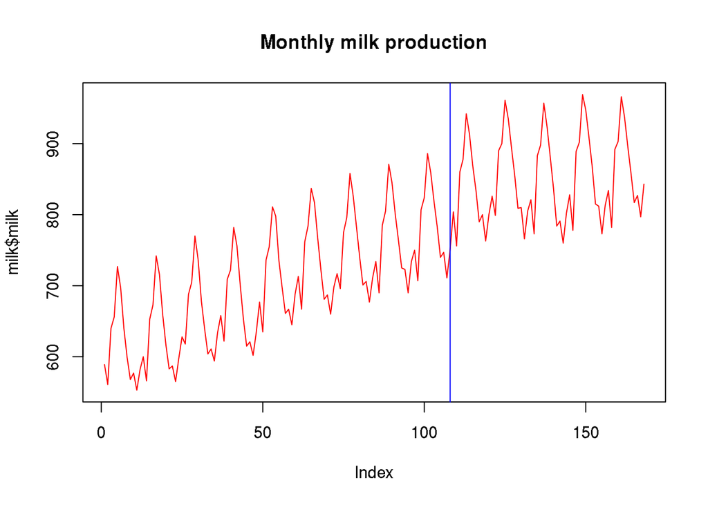

```r
plot(milk$milk, type = "l", col = "red", main = "Monthly milk production")
abline(v = 108, col = "blue")
```

Тренд линейный, а сезонность аддитивная. Выбросов нет, но ряд меняет характер: первые 9 лет ряд однообразно растёт, затем резкий скачок вверх, после которого роста тренда почти нет в течение оставшихся 5 лет. Для прогнозирования оставим только последние 5 лет:

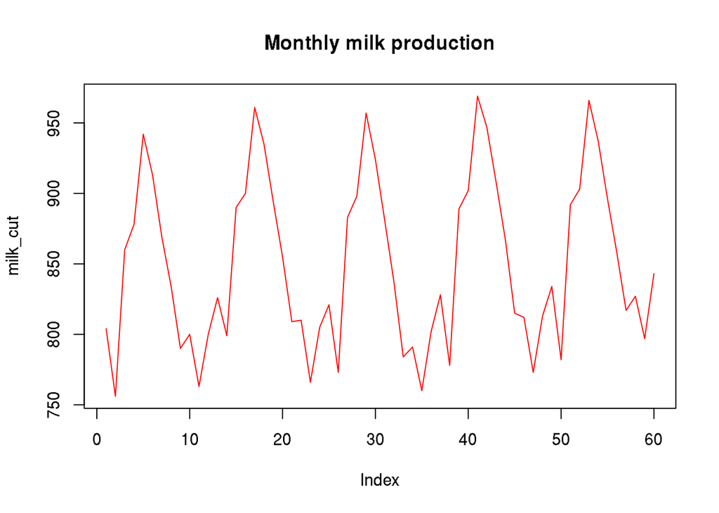

```r
milk_cut <- milk$milk[109:168]
plot(milk_cut, type = "l", col = "red", main = "Monthly milk production")
```

Построим модель с базовым первым месяцем и изучим её качество:

```r
milk.01 <- milk_cut

t <- 1:(60+12)

month.01 <- rep(c(1,0,0,0,0,0,0,0,0,0,0,0), 5+1)
month.02 <- rep(c(0,1,0,0,0,0,0,0,0,0,0,0), 5+1)
month.03 <- rep(c(0,0,1,0,0,0,0,0,0,0,0,0), 5+1)
month.04 <- rep(c(0,0,0,1,0,0,0,0,0,0,0,0), 5+1)
month.05 <- rep(c(0,0,0,0,1,0,0,0,0,0,0,0), 5+1)
month.06 <- rep(c(0,0,0,0,0,1,0,0,0,0,0,0), 5+1)
month.07 <- rep(c(0,0,0,0,0,0,1,0,0,0,0,0), 5+1)
month.08 <- rep(c(0,0,0,0,0,0,0,1,0,0,0,0), 5+1)
month.09 <- rep(c(0,0,0,0,0,0,0,0,1,0,0,0), 5+1)
month.10 <- rep(c(0,0,0,0,0,0,0,0,0,1,0,0), 5+1)
month.11 <- rep(c(0,0,0,0,0,0,0,0,0,0,1,0), 5+1)
month.12 <- rep(c(0,0,0,0,0,0,0,0,0,0,0,1), 5+1)

milk.01[61:72] <- NA

res.01 <- lm(milk.01 ~ t +              month.02 + month.03 + month.04 +
             month.05 + month.06 + month.07 + month.08 + month.09 + month.10 +
             month.11 + month.12)
summary(res.01)
```

```
##
## Call:
## lm(formula = milk.01 ~ t + month.02 + month.03 + month.04 + month.05 +
##     month.06 + month.07 + month.08 + month.09 + month.10 + month.11 +
##     month.12)
##
## Residuals:
##     Min      1Q  Median      3Q     Max
## -19.000  -5.892  -1.171   7.073  27.542
##
## Coefficients:
##              Estimate Std. Error t value Pr(>|t|)
## (Intercept) 809.80486    4.85372 166.842  < 2e-16 ***
## t             0.51181    0.07598   6.736 2.06e-08 ***
## month.02    -45.51181    6.31720  -7.204 4.01e-09 ***
## month.03     59.17639    6.31857   9.365 2.54e-12 ***
## month.04     72.06458    6.32085  11.401 3.94e-15 ***
## month.05    134.35278    6.32405  21.245  < 2e-16 ***
## month.06    106.04097    6.32815  16.757  < 2e-16 ***
## month.07     63.92917    6.33317  10.094 2.36e-13 ***
## month.08     24.01736    6.33909   3.789 0.000430 ***
## month.09    -23.69444    6.34592  -3.734 0.000509 ***
## month.10    -19.20625    6.35364  -3.023 0.004046 **
## month.11    -55.91806    6.36227  -8.789 1.74e-11 ***
## month.12    -15.62986    6.37179  -2.453 0.017933 *
## ---
## Signif. codes:  0 '***' 0.001 '**' 0.01 '*' 0.05 '.' 0.1 ' ' 1
##
## Residual standard error: 9.988 on 47 degrees of freedom
##   (12 observations deleted due to missingness)
## Multiple R-squared:  0.978,  Adjusted R-squared:  0.9724
## F-statistic: 173.9 on 12 and 47 DF,  p-value: < 2.2e-16
```

Диагностически графики модели:

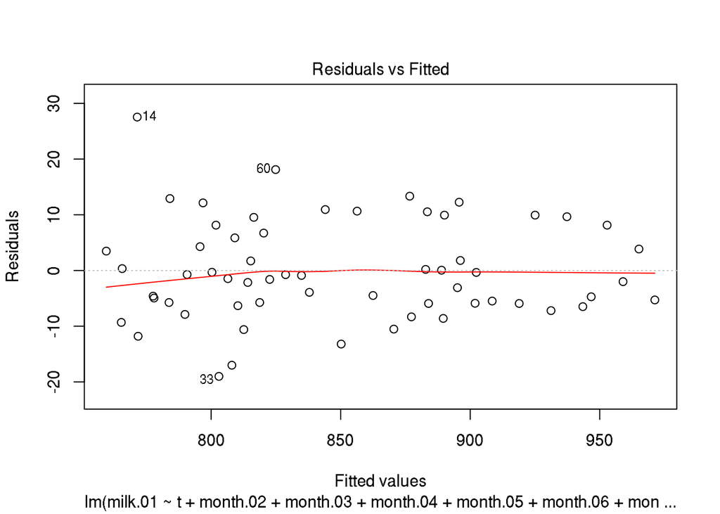

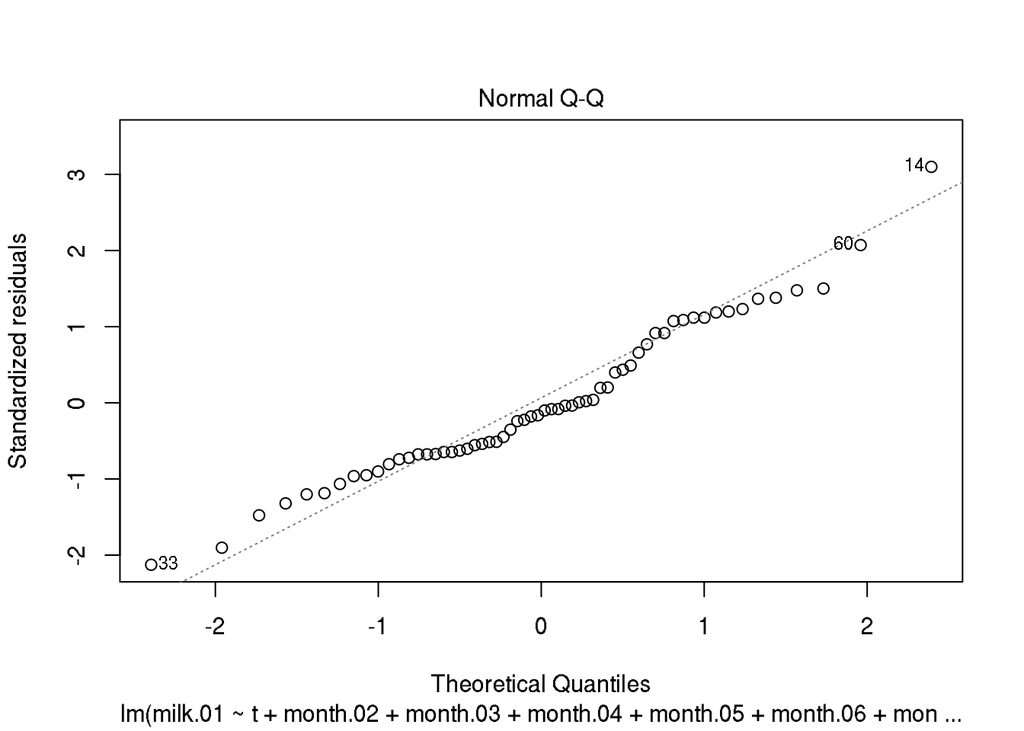

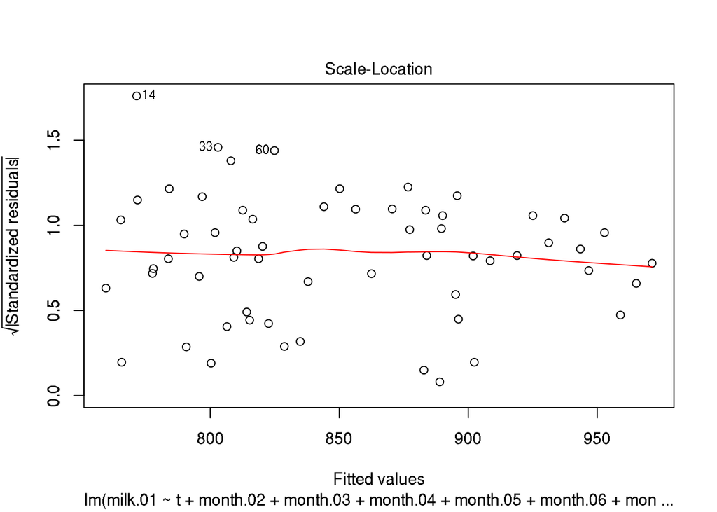

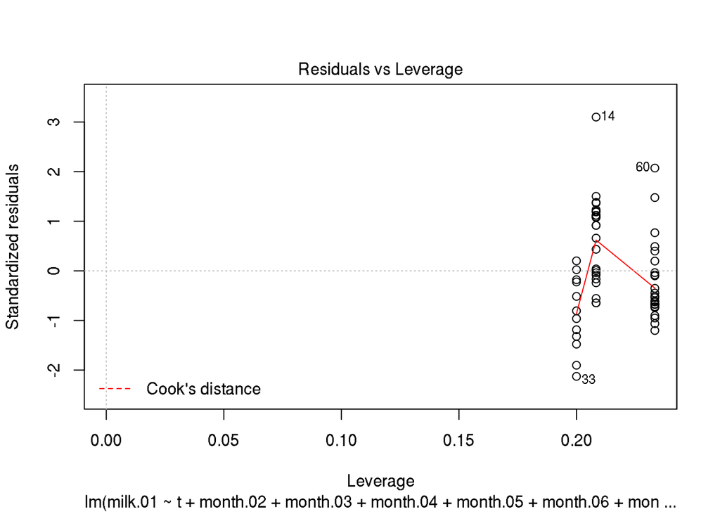

```r
plot(res.01)
```

Дисперсия более-менее однородна на всех данных, значение под номером 14 похоже на выброс. Линии на первом и третьем графиках почти прямые. Данные не выходят за линии уровня для расстояния Кука. QQ-plot показывает отклонения от нормальности, уточним это на гистограмме.

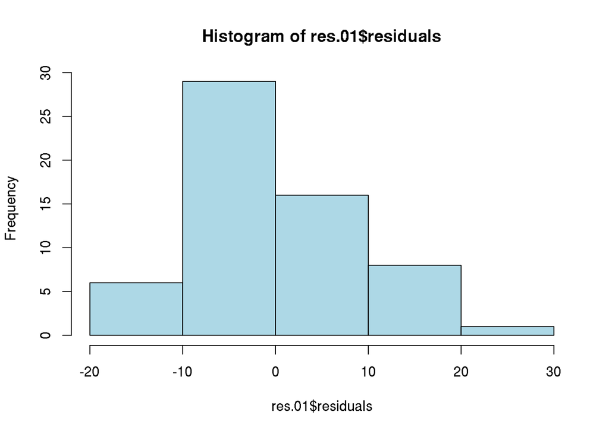

```r
hist(res.01$residuals, col = "lightblue", breaks = 5)
```

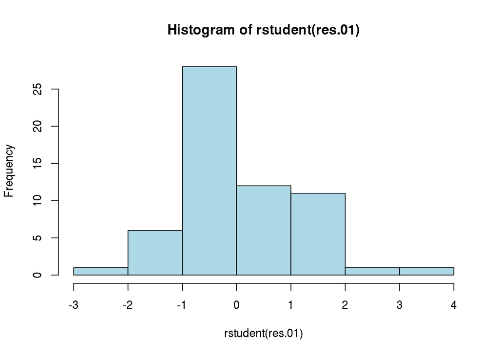

```r
hist(rstudent(res.01), col = "lightblue", breaks = 5)
```

Гистограммы остатков и стьюдентизированных остатков показывают, что распределение достаточно близко к нормальному, хотя и есть отклонения. Расстояние Кука более подробно:

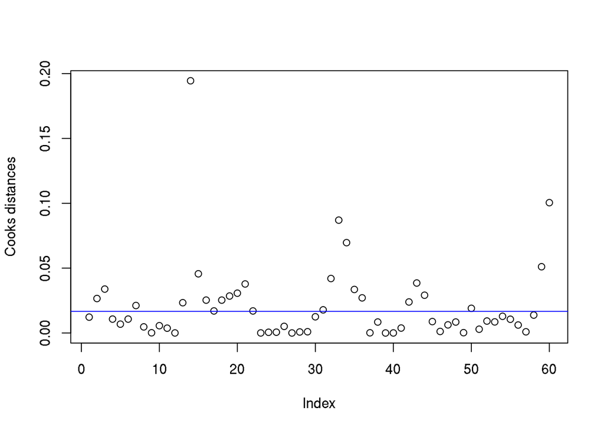

```r
cook.d <-  cooks.distance(res.01)
plot(cook.d,ylab="Cooks distances")

abline(h=1, col = "red")
abline(h=1/60, col = "blue")
```

Все значения меньше 1 (и даже меньше 0.2) – нет критических значений.

Сравним остатки в разных группах:

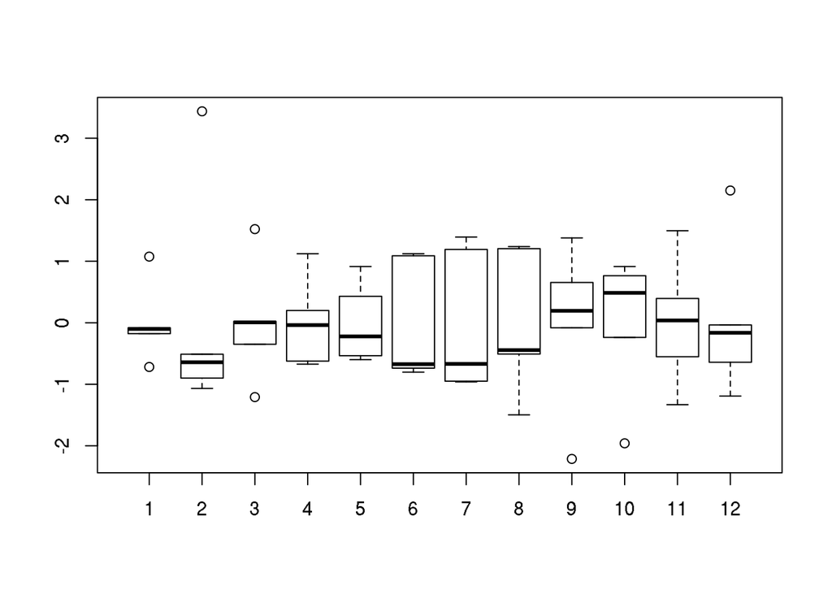

```r
seas.2 <- rep(1:12, 5)[1:60]
boxplot(rstudent(res.01)~seas.2)
```

Остатки по месяцам выглядят очень неоднородно.

Проверим автокорреляцию остатков:

```r
library(lmtest)
dwtest(res.01)
```

```
##
##  Durbin-Watson test
##
## data:  res.01
## DW = 0.32941, p-value = 6.501e-15
## alternative hypothesis: true autocorrelation is greater than 0
```

Нулевая гипотеза отклоняется – среди данных есть автокорреляция.

Проанализируем остатки и для других моделей, рассмотренных в предыдущем задании, постепенно объединяя месяцы. Первый и двенадцатый месяц вместе:

```r
m_01_12 <- month.01 + month.12

res.02 <- lm(milk.01 ~ t + m_01_12 + month.02 + month.03 +         month.05 +
             month.06 + month.07 + month.08 + month.09 + month.10 + month.11)
summary(res.02)
```

```
##
## Call:
## lm(formula = milk.01 ~ t + m_01_12 + month.02 + month.03 + month.05 +
##     month.06 + month.07 + month.08 + month.09 + month.10 + month.11)
##
## Residuals:
##      Min       1Q   Median       3Q      Max
## -19.0000  -6.5034  -0.6758   7.5000  27.2483
##
## Coefficients:
##               Estimate Std. Error t value Pr(>|t|)
## (Intercept)  882.55393    5.19122 170.009  < 2e-16 ***
## t              0.48736    0.07916   6.157 1.44e-07 ***
## m_01_12      -79.81840    5.75265 -13.875  < 2e-16 ***
## month.02    -117.62528    6.64055 -17.713  < 2e-16 ***
## month.03     -12.91264    6.63913  -1.945   0.0577 .
## month.05      62.31264    6.63913   9.386 1.94e-12 ***
## month.06      34.02528    6.64055   5.124 5.28e-06 ***
## month.07      -8.06208    6.64291  -1.214   0.2308
## month.08     -47.94944    6.64621  -7.215 3.45e-09 ***
## month.09     -95.63680    6.65045 -14.381  < 2e-16 ***
## month.10     -91.12416    6.65563 -13.691  < 2e-16 ***
## month.11    -127.81152    6.66175 -19.186  < 2e-16 ***
## ---
## Signif. codes:  0 '***' 0.001 '**' 0.01 '*' 0.05 '.' 0.1 ' ' 1
##
## Residual standard error: 10.5 on 48 degrees of freedom
##   (12 observations deleted due to missingness)
## Multiple R-squared:  0.9752, Adjusted R-squared:  0.9695
## F-statistic: 171.3 on 11 and 48 DF,  p-value: < 2.2e-16
```

Диагностические графики и автокорреляция:

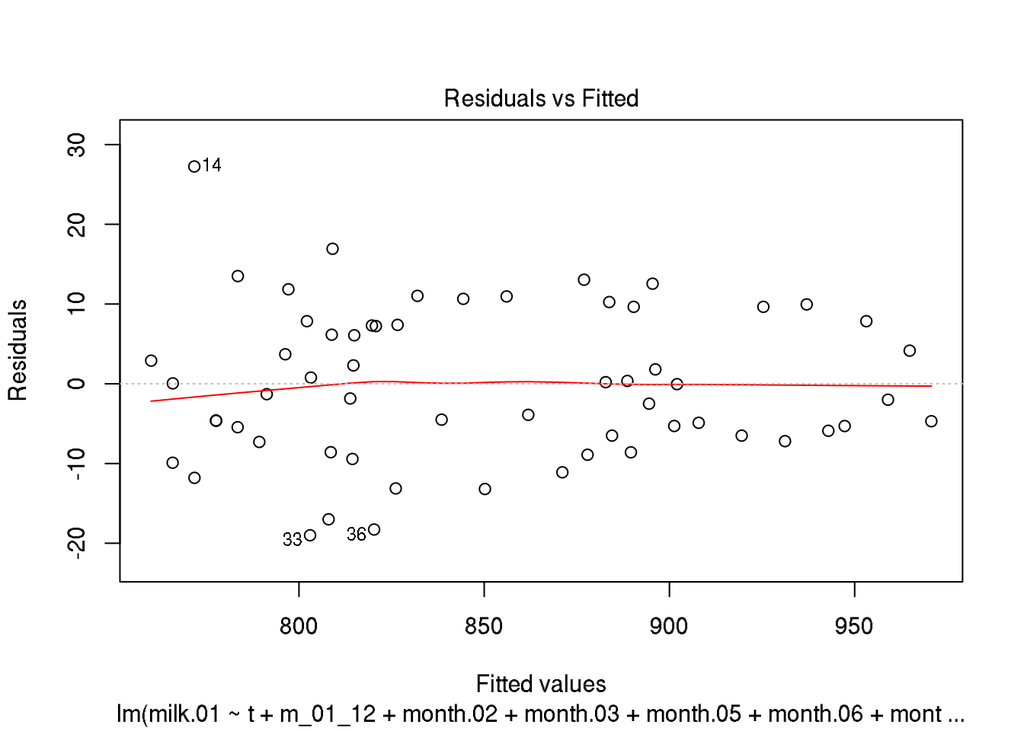

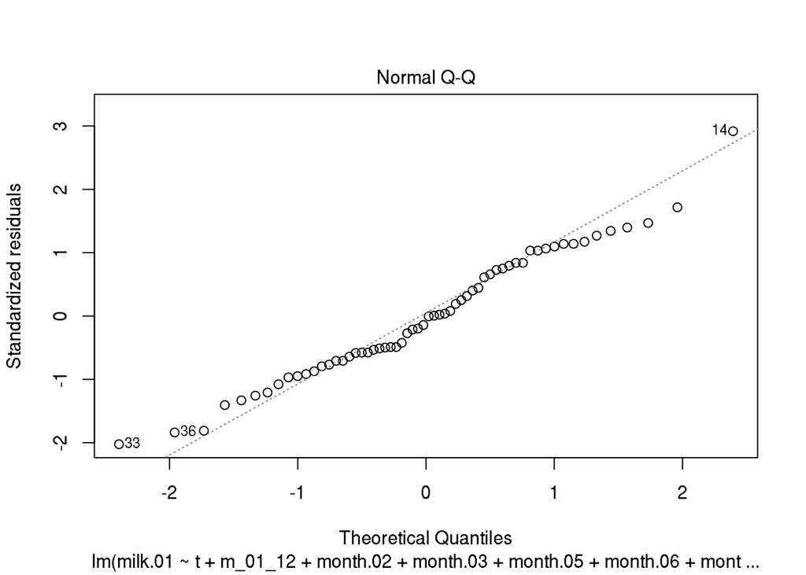

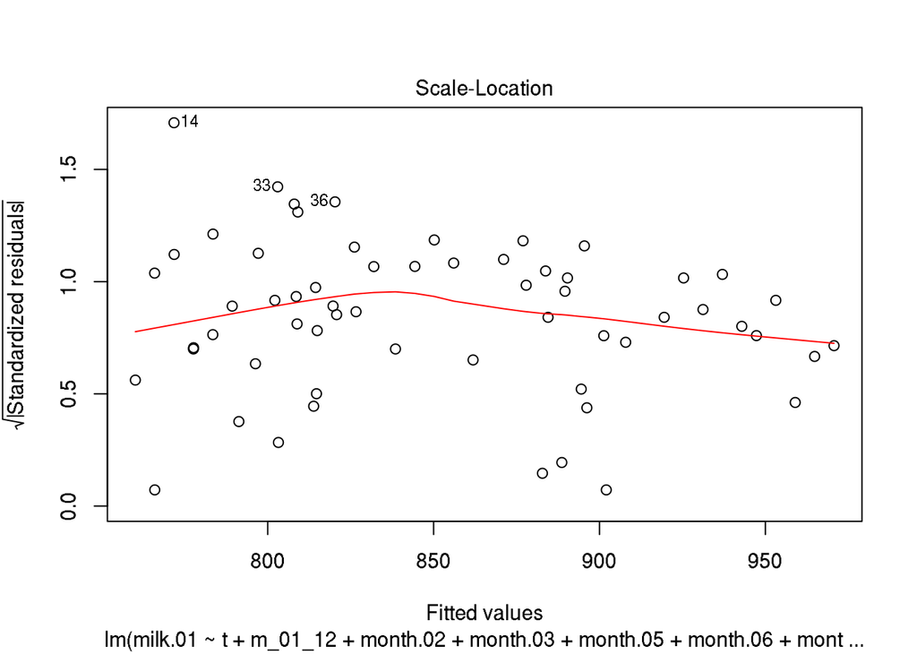

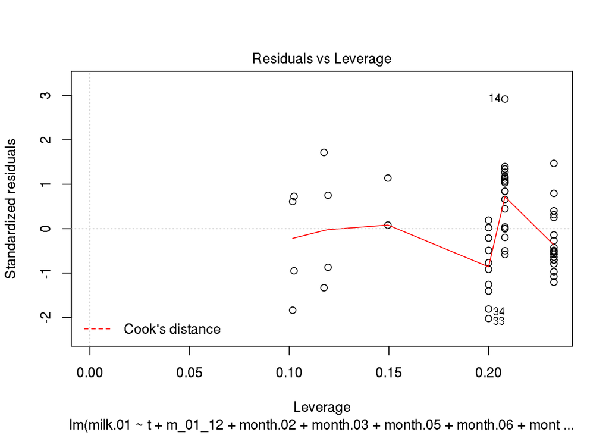

```r
plot(res.02)
```

```r
dwtest(res.02)
```

```
##
##  Durbin-Watson test
##
## data:  res.02
## DW = 0.73356, p-value = 1.485e-07
## alternative hypothesis: true autocorrelation is greater than 0
```

Объединение 3-го и 4-го месяцев:

```r
m_03_04 <- month.03 + month.04

res.03 <- lm(milk.01 ~ t + m_01_12 + month.02 + m_03_04 + month.05 +
             month.06 + month.07 + month.08 + month.09 +       month.11)
summary(res.03)
```

```
##
## Call:
## lm(formula = milk.01 ~ t + m_01_12 + month.02 + m_03_04 + month.05 +
##     month.06 + month.07 + month.08 + month.09 + month.11)
##
## Residuals:
##      Min       1Q   Median       3Q      Max
## -19.0000  -6.6445  -0.6316   7.4800  27.2703
##
## Coefficients:
##              Estimate Std. Error t value Pr(>|t|)
## (Intercept) 791.36736    5.56252 142.268  < 2e-16 ***
## t             0.48920    0.08137   6.012 2.24e-07 ***
## m_01_12      11.31218    5.91710   1.912 0.061762 .
## month.02    -26.48644    6.85554  -3.864 0.000328 ***
## m_03_04      84.67977    5.93387  14.271  < 2e-16 ***
## month.05    153.44598    6.83668  22.445  < 2e-16 ***
## month.06    125.15678    6.83232  18.318  < 2e-16 ***
## month.07     83.06759    6.82893  12.164  < 2e-16 ***
## month.08     43.17839    6.82650   6.325 7.37e-08 ***
## month.09     -4.51080    6.82505  -0.661 0.511760
## month.11    -36.68920    6.82505  -5.376 2.11e-06 ***
## ---
## Signif. codes:  0 '***' 0.001 '**' 0.01 '*' 0.05 '.' 0.1 ' ' 1
##
## Residual standard error: 10.79 on 49 degrees of freedom
##   (12 observations deleted due to missingness)
## Multiple R-squared:  0.9732, Adjusted R-squared:  0.9677
## F-statistic: 177.9 on 10 and 49 DF,  p-value: < 2.2e-16
```

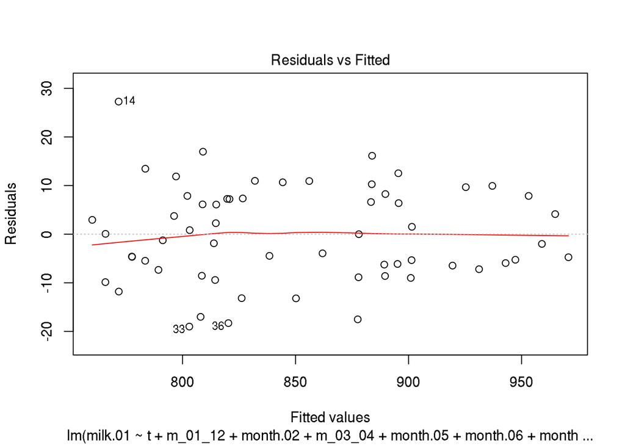

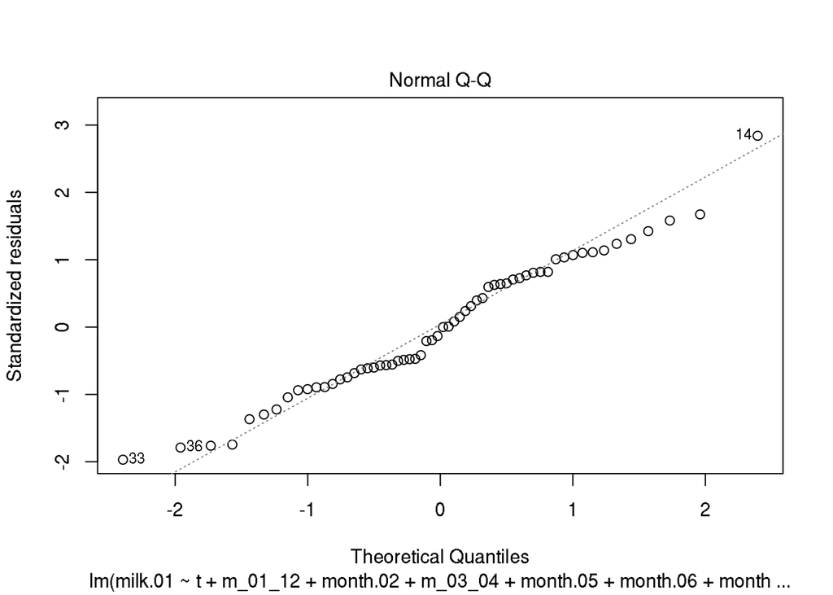

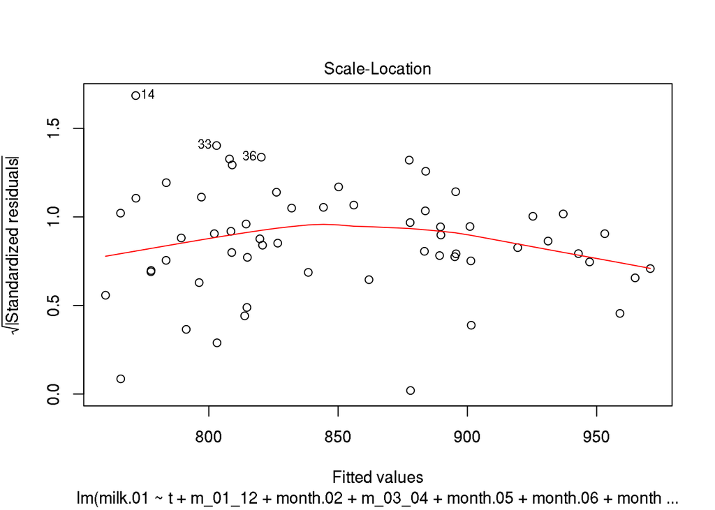

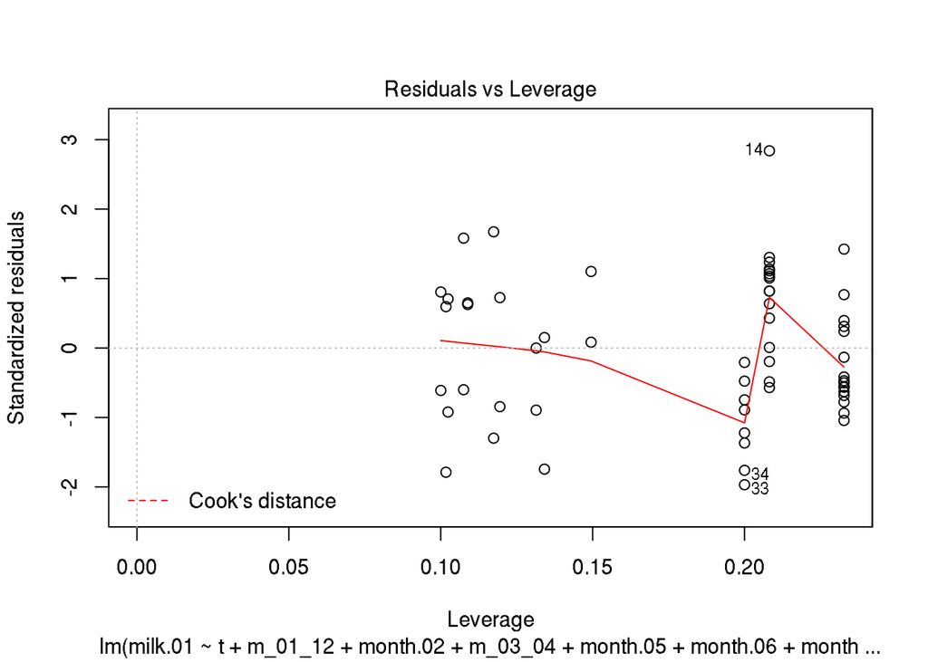

```r
plot(res.03)
```

```r
dwtest(res.03)
```

```
##
##  Durbin-Watson test
##
## data:  res.03
## DW = 0.89931, p-value = 4.687e-06
## alternative hypothesis: true autocorrelation is greater than 0
```

Объединяем 9-й месяц с 10-м.

```r
m_09_10 <- month.09 + month.10

res.04 <- lm(milk.01 ~ t + m_01_12 + month.02 + m_03_04 + month.05 +
                     month.07 + month.08 + m_09_10 + month.11)
summary(res.04)
```

```
##
## Call:
## lm(formula = milk.01 ~ t + m_01_12 + month.02 + m_03_04 + month.05 +
##     month.07 + month.08 + m_09_10 + month.11)
##
## Residuals:
##     Min      1Q  Median      3Q     Max
## -21.255  -6.633   0.000   7.972  27.278
##
## Coefficients:
##               Estimate Std. Error t value Pr(>|t|)
## (Intercept)  916.50490    5.37739 170.437  < 2e-16 ***
## t              0.48984    0.08091   6.054 1.80e-07 ***
## m_01_12     -113.84492    5.87700 -19.371  < 2e-16 ***
## month.02    -151.64065    6.79373 -22.321  < 2e-16 ***
## m_03_04      -40.47541    5.88035  -6.883 9.14e-09 ***
## month.05      28.28984    6.78650   4.169 0.000122 ***
## month.07     -42.08984    6.78650  -6.202 1.06e-07 ***
## month.08     -81.97967    6.78795 -12.077  < 2e-16 ***
## m_09_10     -127.41443    5.88368 -21.656  < 2e-16 ***
## month.11    -161.84918    6.79807 -23.808  < 2e-16 ***
## ---
## Signif. codes:  0 '***' 0.001 '**' 0.01 '*' 0.05 '.' 0.1 ' ' 1
##
## Residual standard error: 10.73 on 50 degrees of freedom
##   (12 observations deleted due to missingness)
## Multiple R-squared:  0.973,  Adjusted R-squared:  0.9681
## F-statistic: 199.9 on 9 and 50 DF,  p-value: < 2.2e-16
```

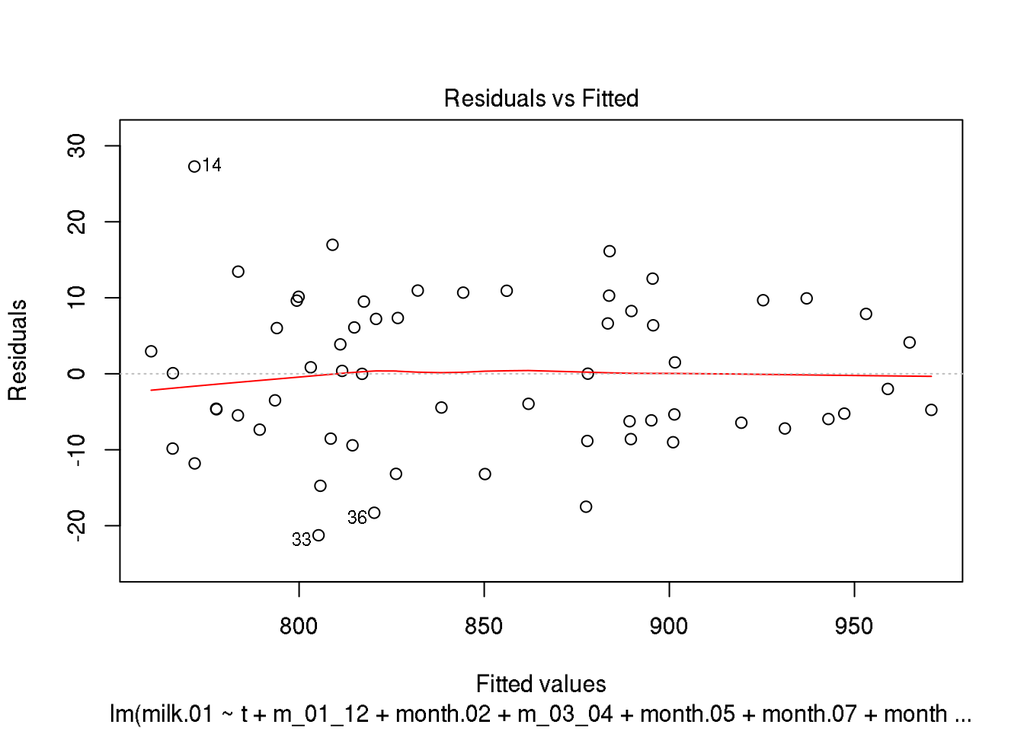

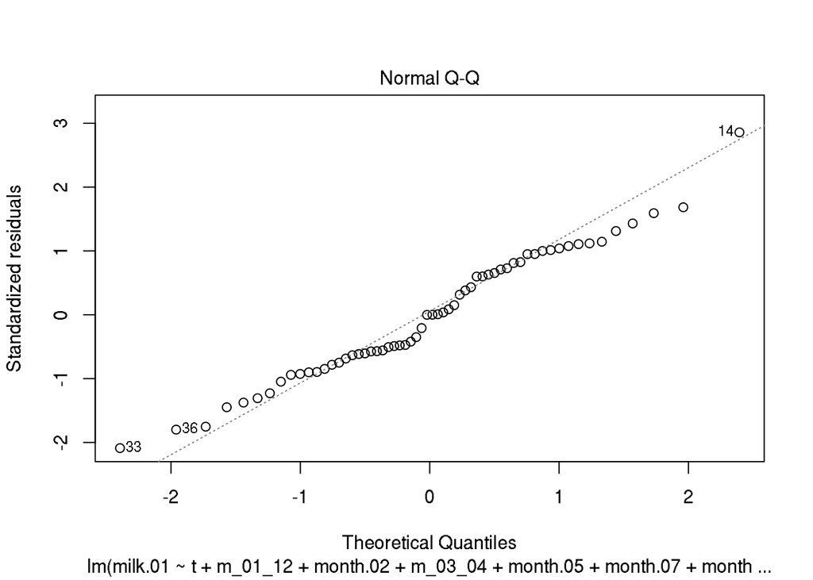

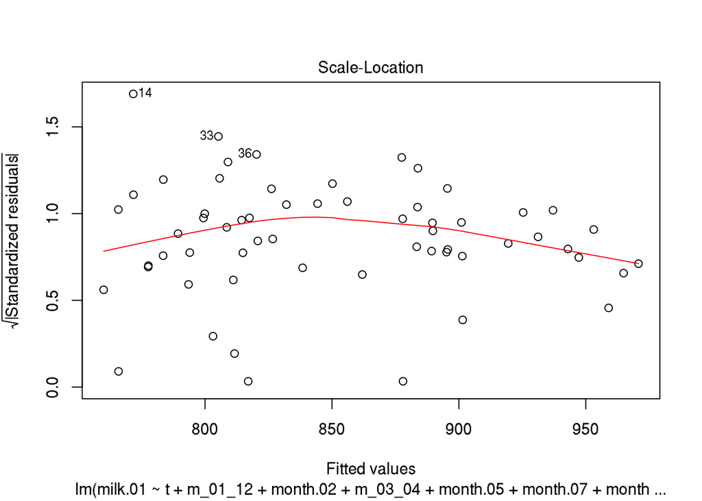

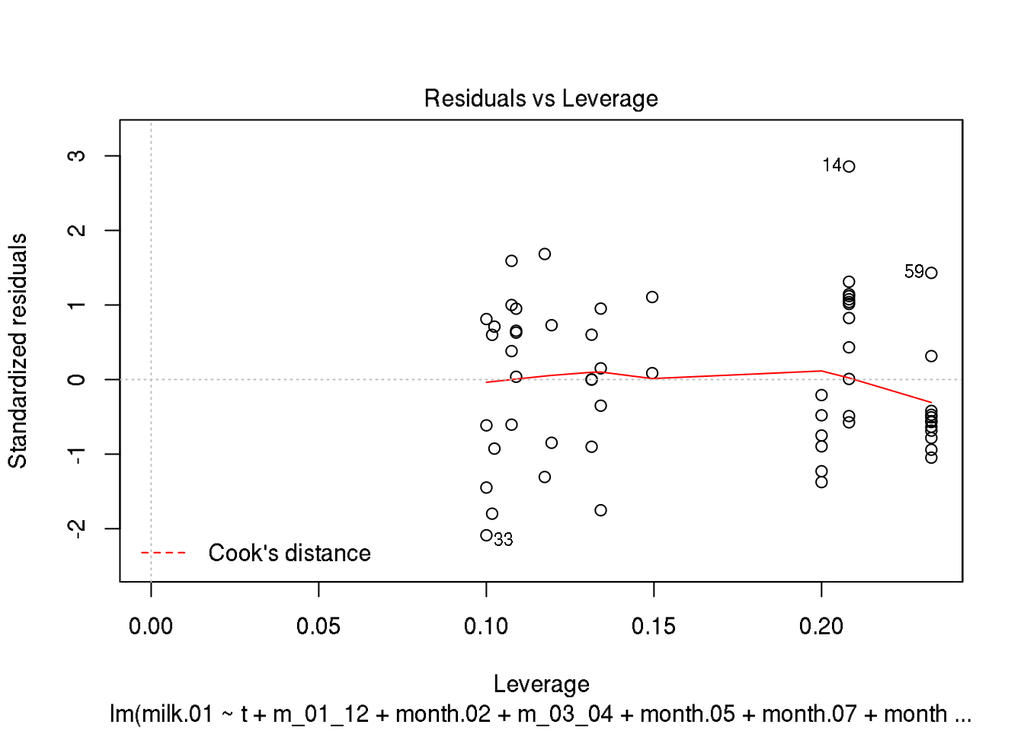

```r
plot(res.04)
```

```r
dwtest(res.04)
```

```
##
##  Durbin-Watson test
##
## data:  res.04
## DW = 0.91792, p-value = 4.101e-06
## alternative hypothesis: true autocorrelation is greater than 0
```

Автокорреляция по-прежнему есть, хотя p-value увеличилось по сравнению с начальной моделью – нужно использовать другую регрессионную модель с учётом этого факта. Диагностические графики для всех моделей хорошие: нет выхода за линии расстояния Кука, дисперсия однородна, кривые на 1 и 3 графиках близки к горизонтальной прямой.